# Parte I K-NN

```python
from Datos import Datos
from ClusteringKMeans import ClusteringKMeans, ClusteringKMeansSKLearn
import EstrategiaParticionado
import Clasificador
import numpy as np
from tabulate import tabulate
%matplotlib inline
import matplotlib.pyplot as plt
```

```python
dataset_1=Datos('./datasets/heart.csv')
print("NOMINAL ATRIBUTOS HEART")
print(dataset_1.nominalAtributos)
print("DICCIONARIO HEART")
print (dataset_1.diccionarios)
print("MATRIZ DE DATOS HEART")
print(dataset_1.datos.head())
dataset_1.normalizarDatos()
print(dataset_1.datos.head())
```

```
NOMINAL ATRIBUTOS HEART
[False, True, True, False, False, False, True, False, True, False, True, True]
DICCIONARIO HEART
{'Age': {}, 'Sex': {'F': 0, 'M': 1}, 'ChestPainType': {'ASY': 0, 'ATA': 1, 'NAP': 2, 'TA': 3}, 'RestingBP': {}, 'Cholesterol': {}, 'FastingBS': {}, 'RestingECG': {'LVH': 0, 'Normal': 1, 'ST': 2}, 'MaxHR': {}, 'ExerciseAngina': {'N': 0, 'Y': 1}, 'Oldpeak': {}, 'ST_Slope': {'Down': 0, 'Flat': 1, 'Up':…
MATRIZ DE DATOS HEART
    Age  Sex  ChestPainType  RestingBP  Cholesterol  FastingBS  RestingECG  \
0  40.0  1.0            1.0      140.0        289.0        0.0         1.0
1  49.0  0.0            2.0      160.0        180.0        0.0         1.0
2  37.0  1.0            1.0      130.0        283.0        0.0         2.0
3  48.0  0.0            0.0      138.0        214.0        0.0         1.0
4  54.0  1.0            2.0      150.0        195.0        0.0         1.0

   MaxHR  ExerciseAngina  Oldpeak  ST_Slope  Class
0  172.0             0.0      0.0       2.0    0.0
1  156.0             0.0      1.0       1.0    1.0
2   98.0             0.0      0.0       2.0    0.0
3  108.0             1.0      1.5       1.0    1.0
4  122.0             0.0      0.0       2.0    0.0
        Age  Sex  ChestPainType  RestingBP  Cholesterol  FastingBS  \
0 -1.432359  1.0            1.0   0.410685     0.824621  -0.551041
1 -0.478223  0.0            2.0   1.490940    -0.171867  -0.551041
2 -1.750404  1.0            1.0  -0.129442     0.769768  -0.551041
3 -0.584238  0.0            0.0   0.302660     0.138964  -0.551041
4  0.051853  1.0            2.0   0.950812    -0.034736  -0.551041

   RestingECG     MaxHR  ExerciseAngina   Oldpeak  ST_Slope  Class
0         1.0  1.382175             0.0 -0.831979       2.0    0.0
1         1.0  0.753746             0.0  0.105606       1.0    1.0
2         2.0 -1.524307             0.0 -0.831979       2.0    0.0
3         1.0 -1.131539             1.0  0.574398       1.0    1.0
4         1.0 -0.581664             0.0 -0.831979       2.0    0.0
```

```python
estrategia = EstrategiaParticionado.ValidacionSimple(5, 0.2)
clasificador = Clasificador.Clasificador()
for N in range(3,13):
    knn = Clasificador.ClasificadorKNN(N)
    errores1 = clasificador.validacion(estrategia, dataset_1, knn, None)
    media = sum(errores1) / len(errores1)
    print("Media de errores para N=" + str(N) + ": " + str(media))
```

```
Numero de particiones realizadas: 5
Media de errores para N=3: 0.17717391304347824
Numero de particiones realizadas: 5
Media de errores para N=4: 0.1826086956521739
Numero de particiones realizadas: 5
Media de errores para N=5: 0.16195652173913044
Numero de particiones realizadas: 5
Media de errores para N=6: 0.15543478260869564
Numero de particiones realizadas: 5
Media de errores para N=7: 0.15
Numero de particiones realizadas: 5
Media de errores para N=8: 0.15108695652173915
Numero de particiones realizadas: 5
Media de errores para N=9: 0.15
Numero de particiones realizadas: 5
Media de errores para N=10: 0.15217391304347827
Numero de particiones realizadas: 5
Media de errores para N=11: 0.13695652173913045
Numero de particiones realizadas: 5
Media de errores para N=12: 0.14130434782608697
```

```python
estrategia = EstrategiaParticionado.ValidacionSimple(5, 0.2)
clasificador = Clasificador.Clasificador()
knn = Clasificador.ClasificadorKNN(11)
errores1 = clasificador.validacion(estrategia, dataset_1, knn, None)

headers = ["Nº particion", "Indice error"]

desviacion_estandar = np.std(errores1)
media = sum(errores1) / len(errores1)
print("Indice de errores por partición:")
table = tabulate(enumerate(errores1, 1), headers, tablefmt="grid")
print(table)
```

```
Numero de particiones realizadas: 5
Indice de errores por partición:
+----------------+----------------+
|   Nº particion |   Indice error |
+================+================+
|              1 |       0.125    |
+----------------+----------------+
|              2 |       0.184783 |
+----------------+----------------+
|              3 |       0.163043 |
+----------------+----------------+
|              4 |       0.206522 |
+----------------+----------------+
|              5 |       0.168478 |
+----------------+----------------+
```

```python
dataset_2=Datos('./datasets/wdbc.csv')
print("NOMINAL ATRIBUTOS WDBC")
print(dataset_2.nominalAtributos)
print("DICCIONARIO WDBC")
print (dataset_2.diccionarios)
print("MATRIZ DE DATOS WDBC")
print(dataset_2.datos.head())
```

```
NOMINAL ATRIBUTOS WDBC
[False, False, False, False, False, False, False, False, False, False, False, False, False, False, False, False, False, False, False, False, False, False, False, False, False, False, False, False, False, False, True]
DICCIONARIO WDBC
{'Atributo1': {}, 'Atributo2': {}, 'Atributo3': {}, 'Atributo4': {}, 'Atributo5': {}, 'Atributo6': {}, 'Atributo7': {}, 'Atributo8': {}, 'Atributo9': {}, 'Atributo10': {}, 'Atributo11': {}, 'Atributo12': {}, 'Atributo13': {}, 'Atributo14': {}, 'Atributo15': {}, 'Atributo16': {}, 'Atributo17': {}, 'A…
MATRIZ DE DATOS WDBC
   Atributo1  Atributo2  Atributo3  Atributo4  Atributo5  Atributo6  \
0      17.99      10.38     122.80     1001.0    0.11840    0.27760
1      20.57      17.77     132.90     1326.0    0.08474    0.07864
2      19.69      21.25     130.00     1203.0    0.10960    0.15990
3      11.42      20.38      77.58      386.1    0.14250    0.28390
4      20.29      14.34     135.10     1297.0    0.10030    0.13280

   Atributo7  Atributo8  Atributo9  Atributo10  ...  Atributo22  Atributo23  \
0     0.3001    0.14710     0.2419     0.07871  ...       17.33      184.60
1     0.0869    0.07017     0.1812     0.05667  ...       23.41      158.80
2     0.1974    0.12790     0.2069     0.05999  ...       25.53      152.50
3     0.2414    0.10520     0.2597     0.09744  ...       26.50       98.87
4     0.1980    0.10430     0.1809     0.05883  ...       16.67      152.20

   Atributo24  Atributo25  Atributo26  Atributo27  Atributo28  Atributo29  \
0      2019.0      0.1622      0.6656      0.7119      0.2654      0.4601
1      1956.0      0.1238      0.1866      0.2416      0.1860      0.2750
2      1709.0      0.1444      0.4245      0.4504      0.2430      0.3613
3       567.7      0.2098      0.8663      0.6869      0.2575      0.6638
4      1575.0      0.1374      0.2050      0.4000      0.1625      0.2364

   Atributo30  Class
0     0.11890    1.0
1     0.08902    1.0
2     0.08758    1.0
3     0.17300    1.0
4     0.07678    1.0

[5 rows x 31 columns]
```

```python
estrategia = EstrategiaParticionado.ValidacionSimple(5, 0.2)
clasificador = Clasificador.Clasificador()
for N in range(3,13):
    knn = Clasificador.ClasificadorKNN(N)
    errores1 = clasificador.validacion(estrategia, dataset_2, knn, None)
    media = sum(errores1) / len(errores1)
    print("Media de errores para N=" + str(N) + ": " + str(media))
```

```
Numero de particiones realizadas: 5
Media de errores para N=3: 0.07192982456140354
Numero de particiones realizadas: 5
Media de errores para N=4: 0.07719298245614034
Numero de particiones realizadas: 5
Media de errores para N=5: 0.06842105263157894
Numero de particiones realizadas: 5
Media de errores para N=6: 0.08596491228070176
Numero de particiones realizadas: 5
Media de errores para N=7: 0.0807017543859649
Numero de particiones realizadas: 5
Media de errores para N=8: 0.08596491228070173
Numero de particiones realizadas: 5
Media de errores para N=9: 0.07368421052631577
Numero de particiones realizadas: 5
Media de errores para N=10: 0.07543859649122805
Numero de particiones realizadas: 5
Media de errores para N=11: 0.06842105263157897
Numero de particiones realizadas: 5
Media de errores para N=12: 0.07543859649122808
```

```python
estrategia = EstrategiaParticionado.ValidacionSimple(5, 0.2)
clasificador = Clasificador.Clasificador()
knn = Clasificador.ClasificadorKNN(9)
errores1 = clasificador.validacion(estrategia, dataset_2, knn, None)

headers = ["Nº particion", "Indice error"]

desviacion_estandar = np.std(errores1)
media = sum(errores1) / len(errores1)
print("Indice de errores por partición:")
table = tabulate(enumerate(errores1, 1), headers, tablefmt="grid")
print(table)
```

```
Numero de particiones realizadas: 5
Indice de errores por partición:
+----------------+----------------+
|   Nº particion |   Indice error |
+================+================+
|              1 |      0.0526316 |
+----------------+----------------+
|              2 |      0.0877193 |
+----------------+----------------+
|              3 |      0.0789474 |
+----------------+----------------+
|              4 |      0.0614035 |
+----------------+----------------+
|              5 |      0.0614035 |
+----------------+----------------+
```

# Parte II - K Means

### Requiere instalación de Tkinter (sudo apt install python3-tk)

```python
dataset = Datos('./datasets/iris.csv')
```

```
0
 [array([5.1, 3.5, 1.4, 0.2]), array([4.9, 3. , 1.4, 0.2]), array([4.7, 3.2, 1.3, 0.2]), array([4.6, 3.1, 1.5, 0.2]), array([5. , 3.6, 1.4, 0.2]), array([5.4, 3.9, 1.7, 0.4]), array([4.6, 3.4, 1.4, 0.3]), array([5. , 3.4, 1.5, 0.2]), array([4.4, 2.9, 1.4, 0.2]), array([4.9, 3.1, 1.5, 0.1]), array([5…

1
 [array([6.9, 3.1, 4.9, 1.5]), array([6.7, 3. , 5. , 1.7]), array([6.3, 3.3, 6. , 2.5]), array([7.1, 3. , 5.9, 2.1]), array([6.3, 2.9, 5.6, 1.8]), array([6.5, 3. , 5.8, 2.2]), array([7.6, 3. , 6.6, 2.1]), array([7.3, 2.9, 6.3, 1.8]), array([6.7, 2.5, 5.8, 1.8]), array([7.2, 3.6, 6.1, 2.5]), array([6…

2
 [array([7. , 3.2, 4.7, 1.4]), array([6.4, 3.2, 4.5, 1.5]), array([5.5, 2.3, 4. , 1.3]), array([6.5, 2.8, 4.6, 1.5]), array([5.7, 2.8, 4.5, 1.3]), array([6.3, 3.3, 4.7, 1.6]), array([4.9, 2.4, 3.3, 1. ]), array([6.6, 2.9, 4.6, 1.3]), array([5.2, 2.7, 3.9, 1.4]), array([5. , 2. , 3.5, 1. ]), array([5…
```

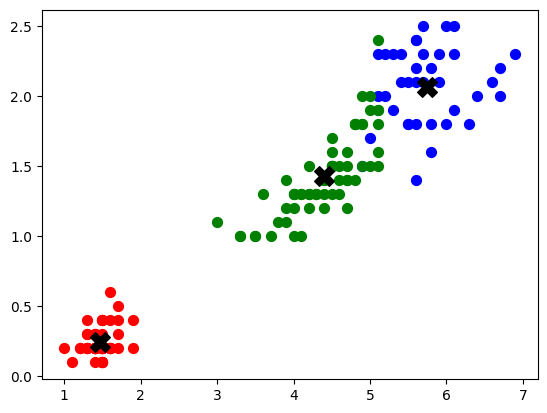

```python
kmeans = ClusteringKMeans(k=3)
clusters = kmeans.clasifica(dataset.datos.iloc[:,:-1])

for i in clusters:
        print(i, "\n", clusters[i], "\n")

colors = ['red', 'blue', 'green']
for i, color in enumerate(colors):
    if clusters[i]:
        cluster_data = np.array(clusters[i])
        plt.scatter(cluster_data[:, 2], cluster_data[:, 3], c=color, s=50)

centroid_data = np.array(kmeans.centroids)
plt.scatter(centroid_data[:, 2], centroid_data[:, 3], c='black', s=200, marker='X')
plt.show()
```

```
0
 [array([5.1, 3.5, 1.4, 0.2]), array([4.9, 3. , 1.4, 0.2]), array([4.7, 3.2, 1.3, 0.2]), array([4.6, 3.1, 1.5, 0.2]), array([5. , 3.6, 1.4, 0.2]), array([5.4, 3.9, 1.7, 0.4]), array([4.6, 3.4, 1.4, 0.3]), array([5. , 3.4, 1.5, 0.2]), array([4.4, 2.9, 1.4, 0.2]), array([4.9, 3.1, 1.5, 0.1]), array([5…

1
 [array([7. , 3.2, 4.7, 1.4]), array([6.4, 3.2, 4.5, 1.5]), array([6.9, 3.1, 4.9, 1.5]), array([5.5, 2.3, 4. , 1.3]), array([6.5, 2.8, 4.6, 1.5]), array([5.7, 2.8, 4.5, 1.3]), array([6.3, 3.3, 4.7, 1.6]), array([6.6, 2.9, 4.6, 1.3]), array([5.2, 2.7, 3.9, 1.4]), array([5. , 2. , 3.5, 1. ]), array([5…
```

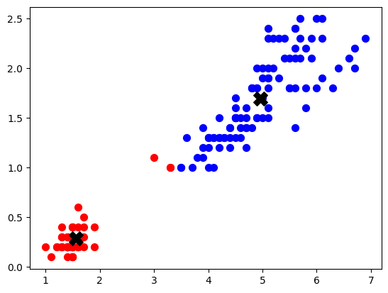

```python
kmeans = ClusteringKMeans(k=2)
clusters = kmeans.clasifica(dataset.datos.iloc[:,:-1])

for i in clusters:
        print(i, "\n", clusters[i], "\n")

colors = ['red', 'blue']
for i, color in enumerate(colors):
    if clusters[i]:
        cluster_data = np.array(clusters[i])
        plt.scatter(cluster_data[:, 2], cluster_data[:, 3], c=color, s=50)

centroid_data = np.array(kmeans.centroids)
plt.scatter(centroid_data[:, 2], centroid_data[:, 3], c='black', s=200, marker='X')
plt.show()
```

```
0
 [array([6.4, 3.2, 4.5, 1.5]), array([5.5, 2.3, 4. , 1.3]), array([6.5, 2.8, 4.6, 1.5]), array([5.7, 2.8, 4.5, 1.3]), array([6.3, 3.3, 4.7, 1.6]), array([4.9, 2.4, 3.3, 1. ]), array([6.6, 2.9, 4.6, 1.3]), array([5.2, 2.7, 3.9, 1.4]), array([5. , 2. , 3.5, 1. ]), array([5.9, 3. , 4.2, 1.5]), array([6…

1
 [array([5.1, 3.5, 1.4, 0.2]), array([5. , 3.6, 1.4, 0.2]), array([5.4, 3.9, 1.7, 0.4]), array([5.4, 3.7, 1.5, 0.2]), array([5.8, 4. , 1.2, 0.2]), array([5.7, 4.4, 1.5, 0.4]), array([5.4, 3.9, 1.3, 0.4]), array([5.1, 3.5, 1.4, 0.3]), array([5.7, 3.8, 1.7, 0.3]), array([5.1, 3.8, 1.5, 0.3]), array([5…

2
 [array([4.9, 3. , 1.4, 0.2]), array([4.7, 3.2, 1.3, 0.2]), array([4.6, 3.1, 1.5, 0.2]), array([4.6, 3.4, 1.4, 0.3]), array([5. , 3.4, 1.5, 0.2]), array([4.4, 2.9, 1.4, 0.2]), array([4.9, 3.1, 1.5, 0.1]), array([4.8, 3.4, 1.6, 0.2]), array([4.8, 3. , 1.4, 0.1]), array([4.3, 3. , 1.1, 0.1]), array([4…

3
 [array([7. , 3.2, 4.7, 1.4]), array([6.9, 3.1, 4.9, 1.5]), array([6.7, 3. , 5. , 1.7]), array([6.3, 3.3, 6. , 2.5]), array([7.1, 3. , 5.9, 2.1]), array([6.3, 2.9, 5.6, 1.8]), array([6.5, 3. , 5.8, 2.2]), array([7.6, 3. , 6.6, 2.1]), array([7.3, 2.9, 6.3, 1.8]), array([6.7, 2.5, 5.8, 1.8]), array([7…
```

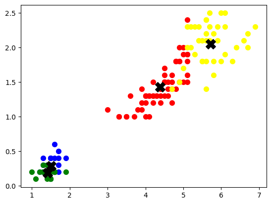

```python
kmeans = ClusteringKMeans(k=4)
clusters = kmeans.clasifica(dataset.datos.iloc[:,:-1])

for i in clusters:
        print(i, "\n", clusters[i], "\n")

colors = ['red', 'blue', 'green', 'yellow']
for i, color in enumerate(colors):
    if clusters[i]:
        cluster_data = np.array(clusters[i])
        plt.scatter(cluster_data[:, 2], cluster_data[:, 3], c=color, s=50)

centroid_data = np.array(kmeans.centroids)
plt.scatter(centroid_data[:, 2], centroid_data[:, 3], c='black', s=200, marker='X')
plt.show()
```

```
0
 [array([5.5, 2.3, 4. , 1.3]), array([5.7, 2.8, 4.5, 1.3]), array([4.9, 2.4, 3.3, 1. ]), array([5.2, 2.7, 3.9, 1.4]), array([5. , 2. , 3.5, 1. ]), array([6. , 2.2, 4. , 1. ]), array([5.6, 2.9, 3.6, 1.3]), array([5.6, 3. , 4.5, 1.5]), array([5.8, 2.7, 4.1, 1. ]), array([5.6, 2.5, 3.9, 1.1]), array([6…

1
 [array([7. , 3.2, 4.7, 1.4]), array([6.4, 3.2, 4.5, 1.5]), array([6.9, 3.1, 4.9, 1.5]), array([6.5, 2.8, 4.6, 1.5]), array([6.3, 3.3, 4.7, 1.6]), array([6.6, 2.9, 4.6, 1.3]), array([5.9, 3. , 4.2, 1.5]), array([6.1, 2.9, 4.7, 1.4]), array([6.7, 3.1, 4.4, 1.4]), array([6.2, 2.2, 4.5, 1.5]), array([6…

2
 [array([5.1, 3.5, 1.4, 0.2]), array([4.9, 3. , 1.4, 0.2]), array([4.7, 3.2, 1.3, 0.2]), array([4.6, 3.1, 1.5, 0.2]), array([5. , 3.6, 1.4, 0.2]), array([5.4, 3.9, 1.7, 0.4]), array([4.6, 3.4, 1.4, 0.3]), array([5. , 3.4, 1.5, 0.2]), array([4.4, 2.9, 1.4, 0.2]), array([4.9, 3.1, 1.5, 0.1]), array([5…

3
 [array([6.3, 3.3, 6. , 2.5]), array([7.1, 3. , 5.9, 2.1]), array([6.5, 3. , 5.8, 2.2]), array([7.6, 3. , 6.6, 2.1]), array([7.3, 2.9, 6.3, 1.8]), array([6.7, 2.5, 5.8, 1.8]), array([7.2, 3.6, 6.1, 2.5]), array([6.8, 3. , 5.5, 2.1]), array([7.7, 3.8, 6.7, 2.2]), array([7.7, 2.6, 6.9, 2.3]), array([6…

4
 [array([5.9, 3.2, 4.8, 1.8]), array([6. , 2.7, 5.1, 1.6]), array([5.8, 2.7, 5.1, 1.9]), array([6.3, 2.9, 5.6, 1.8]), array([6.5, 3.2, 5.1, 2. ]), array([6.4, 2.7, 5.3, 1.9]), array([5.7, 2.5, 5. , 2. ]), array([5.8, 2.8, 5.1, 2.4]), array([6.4, 3.2, 5.3, 2.3]), array([6.5, 3. , 5.5, 1.8]), array([6…
```

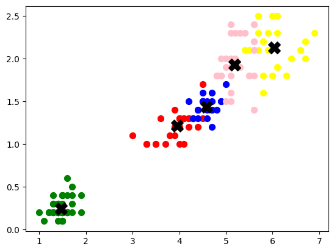

```python
kmeans = ClusteringKMeans(k=5)
clusters = kmeans.clasifica(dataset.datos.iloc[:,:-1])

for i in clusters:
        print(i, "\n", clusters[i], "\n")

colors = ['red', 'blue', 'green', 'yellow', 'pink']
for i, color in enumerate(colors):
    if clusters[i]:
        cluster_data = np.array(clusters[i])
        plt.scatter(cluster_data[:, 2], cluster_data[:, 3], c=color, s=50)

centroid_data = np.array(kmeans.centroids)
plt.scatter(centroid_data[:, 2], centroid_data[:, 3], c='black', s=200, marker='X')
plt.show()
```

Para K=3, comprobar si se puede asignar de forma unívoca cada clúster a un tipo de flor atendiendo a la clase mayoritaria de los patrones agrupados por clúster:

- Como podemos observar, cuando hacemos k=3, se puede marcar practicamente de manera inequivoca que cada cluster pertenece a un tipo de flor aun sabiendo que KMeans no es un algoritmo de clasificación.

Analizar qué tipos de flor se identifican más fácilmente y cuales se confunden entre ellos. Para ello se puede hacer uso de la matriz de confusión multiclase a partir del número de puntos en cada clase y sabiendo que hay 50 ejemplos de cada tipo de flor:

- El tipo de flor que más se puede identificar es "setosa", ya que haciendo la grafica según los parametros del petalo de la flor (los cuales son los más significativos a la hora de clasificar), la clase setosa esta en la parte inferior izquierda mientras que "versicolor" y "virginica" comparten cierto rango.

Probar con otros valores de K=[2,4,5] y comparar los resultados con los obtenidos para K=3. ¿Cuál sería el mejor K para este problema?

- El mejor k para este problema es k=3 ya que solo hay 3 tipos de clases en este dataset.

Analizar si se obtendrían otros resultados normalizando los datos:

- Si normalizasemos los datos, damos el mismo peso a cada uno de ellos, sin embargo, para el caso de este dataset (Iris), podría suponer un mayor "error" al tener los distintos puntos más agrupados.

# Parte III - KNN & KMeans (Scikit-learn)

```python
#KNN SKLearn para dataset "Hearts"
estrategia = EstrategiaParticionado.ValidacionSimple(5, 0.2)
clasificador = Clasificador.Clasificador()
knn = Clasificador.ClasificadorKNNSKLearn(3)
errores1 = clasificador.validacion(estrategia, dataset_1, knn, None)

headers = ["Nº particion", "Indice error"]

desviacion_estandar = np.std(errores1)
media = sum(errores1) / len(errores1)
print("Indice de errores por partición:")
table = tabulate(enumerate(errores1, 1), headers, tablefmt="grid")
print(table)
```

```
Numero de particiones realizadas: 5
Indice de errores por partición:
+----------------+----------------+
|   Nº particion |   Indice error |
+================+================+
|              1 |       0.130435 |
+----------------+----------------+
|              2 |       0.168478 |
+----------------+----------------+
|              3 |       0.152174 |
+----------------+----------------+
|              4 |       0.233696 |
+----------------+----------------+
|              5 |       0.184783 |
+----------------+----------------+
```

```python
#KNN SKLearn para dataset "wdbc"
estrategia = EstrategiaParticionado.ValidacionSimple(5, 0.2)
clasificador = Clasificador.Clasificador()
knn = Clasificador.ClasificadorKNNSKLearn(7)
errores1 = clasificador.validacion(estrategia, dataset_2, knn, None)

headers = ["Nº particion", "Indice error"]

desviacion_estandar = np.std(errores1)
media = sum(errores1) / len(errores1)
print("Indice de errores por partición:")
table = tabulate(enumerate(errores1, 1), headers, tablefmt="grid")
print(table)
```

```
Numero de particiones realizadas: 5
Indice de errores por partición:
+----------------+----------------+
|   Nº particion |   Indice error |
+================+================+
|              1 |      0.0877193 |
+----------------+----------------+
|              2 |      0.0526316 |
+----------------+----------------+
|              3 |      0.0614035 |
+----------------+----------------+
|              4 |      0.0526316 |
+----------------+----------------+
|              5 |      0.0526316 |
+----------------+----------------+
```

Como podemos observar, nuestro modelo de KNN tiene una tasa diferente de fallos, esto es porque nosotros al normalizar los datos, tenemos en cuenta si estos son nominales o no.

```
0
 [array([7. , 3.2, 4.7, 1.4]), array([6.4, 3.2, 4.5, 1.5]), array([5.5, 2.3, 4. , 1.3]), array([6.5, 2.8, 4.6, 1.5]), array([5.7, 2.8, 4.5, 1.3]), array([6.3, 3.3, 4.7, 1.6]), array([4.9, 2.4, 3.3, 1. ]), array([6.6, 2.9, 4.6, 1.3]), array([5.2, 2.7, 3.9, 1.4]), array([5. , 2. , 3.5, 1. ]), array([5…

1
 [array([5.1, 3.5, 1.4, 0.2]), array([4.9, 3. , 1.4, 0.2]), array([4.7, 3.2, 1.3, 0.2]), array([4.6, 3.1, 1.5, 0.2]), array([5. , 3.6, 1.4, 0.2]), array([5.4, 3.9, 1.7, 0.4]), array([4.6, 3.4, 1.4, 0.3]), array([5. , 3.4, 1.5, 0.2]), array([4.4, 2.9, 1.4, 0.2]), array([4.9, 3.1, 1.5, 0.1]), array([5…

2
 [array([6.9, 3.1, 4.9, 1.5]), array([6.7, 3. , 5. , 1.7]), array([6.3, 3.3, 6. , 2.5]), array([7.1, 3. , 5.9, 2.1]), array([6.3, 2.9, 5.6, 1.8]), array([6.5, 3. , 5.8, 2.2]), array([7.6, 3. , 6.6, 2.1]), array([7.3, 2.9, 6.3, 1.8]), array([6.7, 2.5, 5.8, 1.8]), array([7.2, 3.6, 6.1, 2.5]), array([6…
```

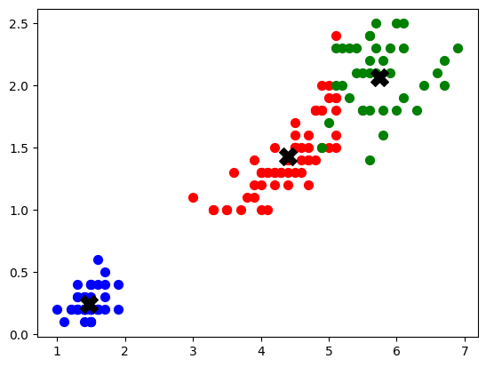

```python
kmeans = ClusteringKMeansSKLearn(k=3)
clusters = kmeans.clasifica(dataset.datos.iloc[:,:-1])

for i in clusters:
        print(i, "\n", clusters[i], "\n")

colors = ['red', 'blue', 'green']
for i, color in enumerate(colors):
    if clusters[i]:
        cluster_data = np.array(clusters[i])
        plt.scatter(cluster_data[:, 2], cluster_data[:, 3], c=color, s=50)

centroid_data = np.array(kmeans.centroids)
plt.scatter(centroid_data[:, 2], centroid_data[:, 3], c='black', s=200, marker='X')
plt.show()
```

### Los modelos de KMeans y KNN de sklearn y el nuestro es practicamente todas las ocasiones el mismo que el nuestro, obteniendo tasas de errores muy semejantes.